# STAT115 Homework 2

Due: Sunday, Feburary 23, 2020 at 11:59pm

# Part I: RNA-seq quality control

For this question, we will examine a series of tools to perform essential quality-control analyses for high-throughput RNA sequencing data.

### Problem I.1 (3pts)

**You are asked by a collaborator to analyze four RNA-seq libraries. She suspects that the libraries are generally of high-quality but is concerned that a sample may have been switched with her benchmates during processing. Execute FastQC, STAR, and RSeQC (tin.py) to determine whether any of the samples exhibit unusual quailty control metrics. Overall, identify the best and worst libraries. Your answer should provide evidence from all three tools. Include screen shots and tables as necessary as if you were delivering a report to the collaborator.**

```
Sequencing data:
/n/stat115/2020/HW2/raw_data

modules: fastqc/0.11.8-fasrc01, STAR/2.6.0c-fasrc01
index: /n/stat115/2020/HW2/star_hg38_index
bed: /n/stat115/2020/HW2/hg38_RefSeq.bed
```

```
Hint: not required but helpful to run STAR with these parameters:
--outSAMtype BAM SortedByCoordinate
--readFilesCommand zcat
```

Student response

### Problem I.2 (0.5pt; graduate students only)

**Your collaborator recalls that one of her samples was left on the bench for a couple of days before the full RNA-seq library was processed. Using the metrics from the question above, can you identify this sample? Provide your rationale.**

Student response

# Part II: Pseudoalignment

### Problem II.1 (1pt)

**Process the 4 sequencing libraries with Salmon introduced in the previous question. Identify the transcript and gene with the highest expression in each library from the Salmon output.**

```
module: salmon/0.12.0-fasrc01
index: /n/stat115/2020/HW2/salmon_hg38_index
```

Student response

### Problem II.2 (1pt)

**Report the relative speed of Salmon and STAR for the analyses of these four samples. Comment on your results based on the lecture material.**

```
Hint: you can parse the times from log files or use the `time` tool in the command line...
e.g. time sleep 2
```

Student response

### Problem II.3 (1pt; graduate students only)

**Plot the relationship between effective length, normalized read counts, TPM, and FPKM for runX from the Salmon output. Comment on the relative utility of each metric when analyzing gene expression data.**

Student response

# Part III: Differential expression

In 2014, a controversial manuscript from Lin et al. argued that, based on RNA-seq of several tissues from both mouse and human, fundamental physiological differences existed between these two organisms. Here, we will investigate these claims for a subset of the data analyzed. (Note: a copy of this manuscript is included as the `part3_4-manuscript.pdf` file associated with this homework.) The provided data is a counts matrix of the samples with the following conventions:

```
row: <mouse>_<human> gene name (e.g. Stag2_STAG2)
column: <organism>_<tissue>_<batch> sample identifier (e.g. human_adipose_3)
```

### Problem III.1 (1pt)

**Perform a principle component analysis of the samples using the top 5,000 most variable genes as features. Indicate the species, tissue, and batch per sample plot. Do the results support the conclusions of the original paper? Do the results suggest the presence of a batch effect?**

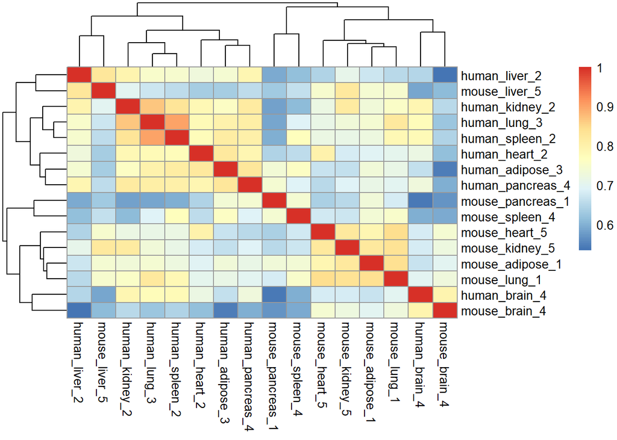

```r
# Import processed raw counts processed 라고 돼어있으니까 legnth로 나눠준 것 같다. 아마도
counts <- readRDS("../data/part3_counts.rds")

# Perform a log TPM normalization
log2tpm <- sapply(1:dim(counts)[2], function(idx){
  log2((counts[,idx]/sum(counts[,idx]) * 1000000) + 1)
})
colnames(log2tpm) <- colnames(counts)
pheatmap(cor(log2tpm)) # tpm값으로 샘플간의 cor이 얼마나 있나 확인
```

```r
#sapply : 벡터, 리스트, 표현식, 데이터 프레임 등에 함수를 적용하고 그 결과를 벡터 또는 행렬로 반환한다. 결국 벡터의 하나의 원소씩 계산해 주는듯
# +1은 log0값을 피해주기 위해 넣어줌
# Continue analysis here.
```

**Perform a principle component analysis of the samples using the top 5,000 most variable genes as features. Indicate the species, tissue, and batch per sample plot. Do the results support the conclusions of the original paper? Do the results suggest the presence of a batch effect?** Student response

```r
rowVars <- function(x, ...) {
  rowSums((x - rowMeans(x, ...))^2, ...)/(dim(x)[2] - 1)
}
#x < 행렬의 각 원소에 x, ... < 행렬 전체 선택
rv <- rowVars(log2tpm) # rv = most variable gene을 고르기 위함
head(rv)
```

```
##           Stag2_STAG2           Stag1_STAG1           Gosr2_GOSR2
##            1.15871474            0.65888022            2.83791881
## 4933434E20Rik_C1orf43             Art5_ART5             Art1_ART1
##            2.00860277            0.04591524            0.70728986
```

```r
cutoff <- sort(rv, decreasing = TRUE)[5000]
log2tpm_variable <- log2tpm[rv >= cutoff, ]
feature_data <- data.frame(str_split_fixed(colnames(log2tpm), "_", 3))
colnames(feature_data) <- c("organism", "tissue", "batch")
sample_data_pca <- data.frame(feature_data,prcomp(log2tpm_variable, scale = TRUE, center = TRUE)$rotation)
pca_result<- prcomp(log2tpm_variable, scale = TRUE, center = TRUE)
#데이터프레임이 나란히 있으면 옆에다 합침
#This standardize the input data so that it has zero mean and variance one before doing PCA
#   scale => 컬럼의 분산을 1로 할것이냐 아니냐표준화 여부(변수들의 단위가 다를 경우, 표준화가 바람직함)
# center = 컬럼의 평균을 0으로 할 것이냐 아니냐
#https://cmdlinetips.com/2019/04/introduction-to-pca-with-r-using-prcomp/
# rotation은 주성분 변환 계수,x(주성분 변환이된 데이터)
#pca_result$center #mean each column before scale
#pca_result$scale^2 #The square of scale gives us the variances of each column of our data before scaling.
#pca_result$rotation#$rotation shows you how much each gene influenced each PC linear combination (called 'scores')
summary(pca_result)
```

```
## Importance of components:
##                           PC1    PC2     PC3     PC4     PC5     PC6     PC7
## Standard deviation     2.6236 1.3107 1.24410 1.16382 0.94283 0.88643 0.81786
## Proportion of Variance 0.4302 0.1074 0.09674 0.08466 0.05556 0.04911 0.04181
## Cumulative Proportion  0.4302 0.5376 0.63431 0.71897 0.77453 0.82364 0.86544
##                            PC8     PC9    PC10    PC11    PC12    PC13    PC14
## Standard deviation     0.64330 0.63171 0.51710 0.49055 0.44876 0.42964 0.40960
## Proportion of Variance 0.02586 0.02494 0.01671 0.01504 0.01259 0.01154 0.01049
## Cumulative Proportion  0.89131 0.91625 0.93296 0.94800 0.96059 0.97212 0.98261
##                           PC15   PC16
## Standard deviation     0.38762 0.3578
## Proportion of Variance 0.00939 0.0080
## Cumulative Proportion  0.99200 1.0000
```

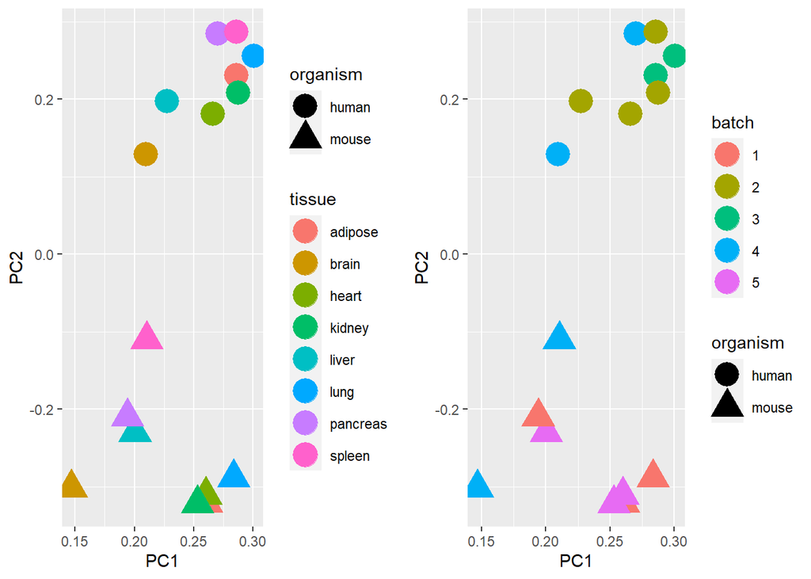

```r
sample_data_pca <- data.frame(feature_data,prcomp(log2tpm_variable, scale = TRUE, center = TRUE)$rotation) #데이타프레임 합치기
p1 <- ggplot(sample_data_pca, aes(x = PC1, y = PC2, shape = organism, color = tissue )) +
  geom_point(size= 7)
p2 <- ggplot(sample_data_pca, aes(x = PC1, y = PC2, color = batch, shape = organism,)) +
  geom_point(size= 7)
grid.arrange(p1,p2, ncol = 2)
```

해석 : organism별로 분리가 된다. > batch를 보니 batch 끼리 뭉쳐있다. batch effect 때문에 그런것 아니냐? > batch effect 제거해 보자. 아마도 5000 most 분산이 큰 유전자들만 사용해서 PCA분석을 하면 샘플간의 데이타가 더 퍼져있게 나오는것 같다.

### Problem III.2 (1pt)

**Run COMBAT on the samples to remove the batch effect. Visualize the results using a similar principle component analysis as the question above. Provide evidence that the batch effects are successfully adjusted. Do these results change the primary interpretation of the results?**

```r
combat_dat <- ComBat(log2tpm_variable, sample_data_pca$batch, par.prior = TRUE)
```

```
## Found 416 genes with uniform expression within a single batch (all zeros); these will not be adjusted for batch.
```

```
## Found5batches
```

```
## Adjusting for0covariate(s) or covariate level(s)
```

```
## Standardizing Data across genes
```

```
## Fitting L/S model and finding priors
```

```
## Finding parametric adjustments
```

```
## Adjusting the Data
```

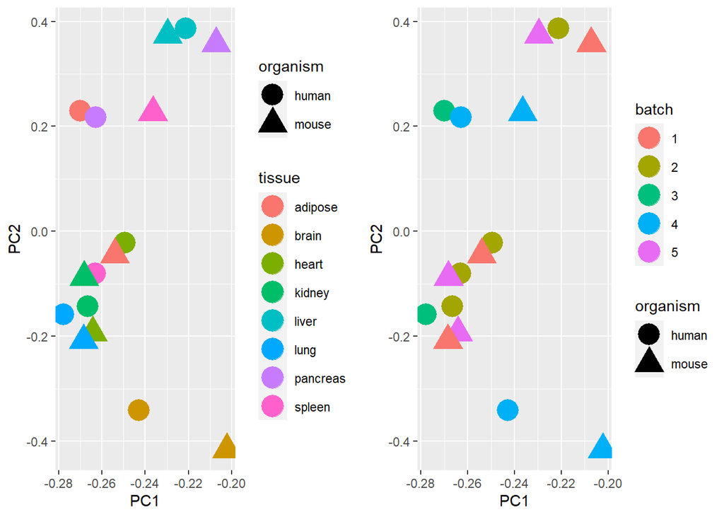

```r
feature_data_pca_combat <- data.frame(
  feature_data,
  prcomp(combat_dat, scale = TRUE, center = TRUE)$rotation)

p3 <- ggplot(feature_data_pca_combat, aes(x = PC1, y = PC2, shape = organism, color = tissue )) +
  geom_point(size= 7)
p4 <- ggplot(feature_data_pca_combat, aes(x = PC1, y = PC2, color = batch, shape = organism,)) +
  geom_point(size= 7)
grid.arrange(p3,p4, ncol = 2)
```

Student response  
batch effect 적용 이후에, 생명체 단위로 PC1,PC2의 구별은 줄어들었다. >tissue 별로 발현이 비슷하게 그룹핑이 되었다. > organism단위의 분리보다는 tissue의 영향이 더 크다. Q. batch effect 제거 후 batch 별로 색깔을 입히는게 무슨 의미가 있나?

### Problem III.3 (1pts)

**Run DESeq2 adjusting for the batch effect to identify differentially-expressed genes between the lung and adipose tissue. Report the number of statistically-significant genes as well as whether they are more highly expressed in either adipose tissue or lung tissue.**

```r
#DESeq2 에서 batch effect를 고려해 줄 수있나? > 어떻게? 방법이 있는것 같은데 모르겠다.
#그래서 위에서 batch effect를 조정해준 tpm값으로
#counts_combat <- sapply(1:dim(combat_dat)[2], function(idx){
#  (combat_dat[,idx] - 1)* (sum([,idx]) * 1000000)
#})
#sum(combat_dat[,1])
sampletype <- factor(c(rep("adipose",2), rep("lung", 2)))
batch <- factor(c(3,1,3,1))
count_Deseq2 <- counts[,c(1,6,9,14)]
count_Deseq2 <- count_Deseq2[,c(1,3,2,4)]
meta <- data.frame(sampletype, batch, row.names = c("h_a(3)","m_a(1)","h_l(3)","m_l(1)"))
colnames(count_Deseq2) <- rownames(meta)
#human
dds <- DESeqDataSetFromMatrix(countData = count_Deseq2,
                              colData = meta,
                              design= ~ batch + sampletype)
dds <- DESeq(dds)
resultsNames(dds)
```

```
## [1] "Intercept"                  "batch_3_vs_1"
## [3] "sampletype_lung_vs_adipose"
```

```r
res <- results(dds, name="sampletype_lung_vs_adipose",alpha = 0.05)
res
```

```
## log2 fold change (MLE): sampletype lung vs adipose
## Wald test p-value: sampletype lung vs adipose
## DataFrame with 14744 rows and 6 columns
##                         baseMean log2FoldChange     lfcSE      stat    pvalue
##                        <numeric>      <numeric> <numeric> <numeric> <numeric>
## Stag2_STAG2           4463.25672       1.674481  0.677147  2.472846 0.0134042
## Stag1_STAG1           1604.40151       0.130968  0.692788  0.189045 0.8500573
## Gosr2_GOSR2            618.30348      -0.748159  0.775437 -0.964822 0.3346340
## 4933434E20Rik_C1orf43 2190.46398       1.296617  0.683304  1.897569 0.0577529
## Art5_ART5                1.85944       1.578133  4.820008  0.327413 0.7433556
## ...                          ...            ...       ...       ...       ...
## Fam83e_FAM83E            9.83133       1.264684   2.80282  0.451218  0.651832
## Fam83b_FAM83B           19.27455      -0.511415   2.13917 -0.239072  0.811050
## Fam83f_FAM83F           10.72245      -6.542555   3.61582 -1.809425  0.070385
## Fam83h_FAM83H           51.49073      -1.202352   1.62847 -0.738330  0.460314
## Fam83g_FAM83G            9.57220      -0.859205   2.75080 -0.312348  0.754776
##                            padj
##                       <numeric>
## Stag2_STAG2            0.103188
## Stag1_STAG1            0.937778
## Gosr2_GOSR2            0.597064
## 4933434E20Rik_C1orf43  0.237339
## Art5_ART5                    NA
## ...                         ...
## Fam83e_FAM83E                NA
## Fam83b_FAM83B                NA
## Fam83f_FAM83F                NA
## Fam83h_FAM83H          0.704816
## Fam83g_FAM83G                NA
```

```r
genename <- rownames(res)
# Filter genes by zero expression
res <- res[which(res$baseMean != 0),] # 발현량이 0인애들 제거
res <- res[which(!is.na(res$padj)),] # padj가 0인애들(결측값) 제거
res <- res[order(res$padj),]
nrow(res[res$padj<=0.05,])
```

```
## [1] 969
```

```r
#summary(res, alpha=0.05)
#res <- lfcShrink(dds, coef="condition_trt_vs_untrt", type="apeglm")
```

combat_dat < 이건 batch effect 고려해 준 dataframe 이걸 다시 count로 바꾸자. 어떻게? 역 연산

Student response

### Problem III.4 (1pts)

**Identify the top 5 most differentially expressed genes that are overexpressed in each of the tissues. Comment on the biological relevance of these. It may be useful to use data from the GTEx consortium when interpreting your result.**

```r
rownames(res[1:5,])
```

```
## [1] "Lamp3_LAMP3"     "Scgb3a2_SCGB3A2" "Sftpb_SFTPB"     "Scgb1a1_SCGB1A1"
## [5] "Slc6a14_SLC6A14"
```

GTEx link: https://www.gtexportal.org/home They are lung specific genes from GTEx data comfirmed.

### Problem III.5 (1pts)

**Visualize the differential gene expression values by making a volcano and an MA plot to summarize the differences between the two tissues. Be sure to use the `lfcShrink` function to get more robust estimates of the fold-changes for genes.**

```r
#plotMA(res)
res_shrunken <- lfcShrink(dds, coef="sampletype_lung_vs_adipose", type="apeglm")
```

```
## using 'apeglm' for LFC shrinkage. If used in published research, please cite:
##     Zhu, A., Ibrahim, J.G., Love, M.I. (2018) Heavy-tailed prior distributions for
##     sequence count data: removing the noise and preserving large differences.
##     Bioinformatics. https://doi.org/10.1093/bioinformatics/bty895
```

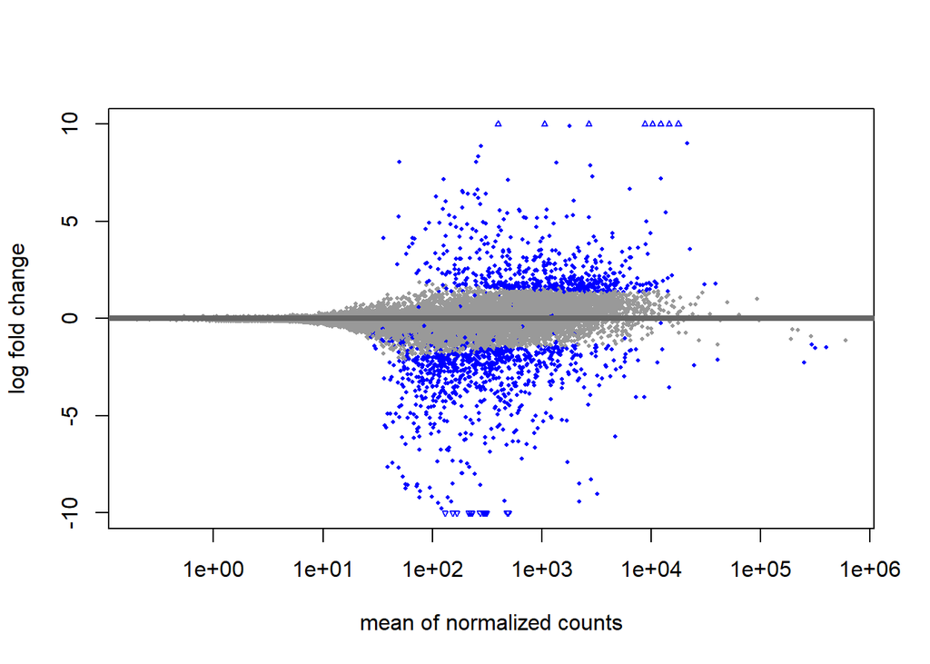

```r
plotMA(res_shrunken ,ylim=c(-10,10))
```

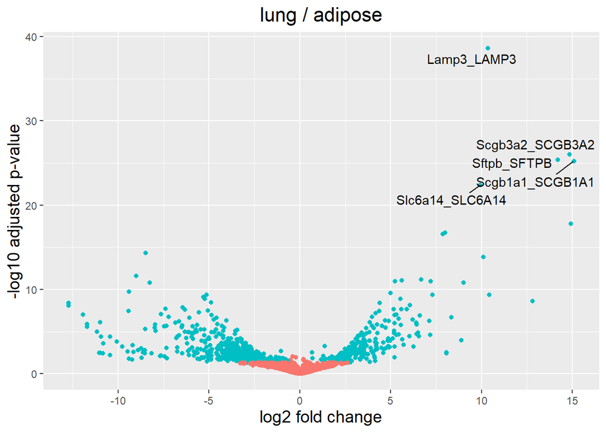

```r
res_shrunken_mutate <- as_tibble(res_shrunken)
res_shrunken_mutate <-  res_shrunken_mutate %>%
    mutate(threshold_OE = padj < 0.05 & abs(log2FoldChange) >= 0.58)
res_shrunken_mutate[,"genename"] <- genename
res_shrunken_mutate <- res_shrunken_mutate %>% arrange(padj)
genename5 <- unlist((res_shrunken_mutate[1:5,"genename"]))
res_shrunken_mutate[,"genename5"] <- c(genename5,rep("", times=14739))

ggplot(res_shrunken_mutate, aes(x = log2FoldChange, y = -log10(padj))) +
    geom_point(aes(colour = threshold_OE)) +
    geom_text_repel(aes(label = genename5)) +
    ggtitle("lung / adipose") +
    xlab("log2 fold change") +
    ylab("-log10 adjusted p-value") +
    #scale_y_continuous(limits = c(0,50)) +
    theme(legend.position = "none",
          plot.title = element_text(size = rel(1.5), hjust = 0.5),
          axis.title = element_text(size = rel(1.25)))
```

```r
#summary(res_shrunken, alpha=0.05)
```

Student response

### Problem III.6 (1pts; graduate students only)

**Rerun differential gene expression analyses without accounting for the batch effect. Compare the number of differentially expressed genes and anecdotes of top differentially expressed genes. Are the numbers of differentially expressed genes before/after the batch effect consistent with what you would have expected? Comment on the biological relevance of the top genes.**

```r
dds_wo <- DESeqDataSetFromMatrix(countData = count_Deseq2,
                              colData = meta,
                              design= ~ sampletype)
dds_wo <- DESeq(dds_wo)
resultsNames(dds_wo)
```

```
## [1] "Intercept"                  "sampletype_lung_vs_adipose"
```

```r
res_wo <- results(dds_wo, name="sampletype_lung_vs_adipose",alpha = 0.05)
res_wo
```

```
## log2 fold change (MLE): sampletype lung vs adipose
## Wald test p-value: sampletype lung vs adipose
## DataFrame with 14744 rows and 6 columns
##                         baseMean log2FoldChange     lfcSE      stat    pvalue
##                        <numeric>      <numeric> <numeric> <numeric> <numeric>
## Stag2_STAG2           4463.25672       1.766198   1.05656  1.671654 0.0945927
## Stag1_STAG1           1604.40151       0.131664   1.11189  0.118415 0.9057391
## Gosr2_GOSR2            618.30348      -0.444041   1.54171 -0.288018 0.7733331
## 4933434E20Rik_C1orf43 2190.46398       1.337639   1.20613  1.109035 0.2674150
## Art5_ART5                1.85944       2.680013   4.79899  0.558454 0.5765347
## ...                          ...            ...       ...       ...       ...
## Fam83e_FAM83E            9.83133       0.748590   2.39212  0.312939 0.7543267
## Fam83b_FAM83B           19.27455      -1.181610   2.04218 -0.578601 0.5628582
## Fam83f_FAM83F           10.72245      -6.767211   3.02105 -2.240017 0.0250898
## Fam83h_FAM83H           51.49073      -0.497083   1.57380 -0.315848 0.7521178
## Fam83g_FAM83G            9.57220      -1.167918   2.21390 -0.527538 0.5978197
##                            padj
##                       <numeric>
## Stag2_STAG2            0.452926
## Stag1_STAG1            0.979949
## Gosr2_GOSR2            0.948002
## 4933434E20Rik_C1orf43  0.695112
## Art5_ART5                    NA
## ...                         ...
## Fam83e_FAM83E                NA
## Fam83b_FAM83B          0.869620
## Fam83f_FAM83F                NA
## Fam83h_FAM83H          0.941584
## Fam83g_FAM83G                NA
```

```r
genename_wo <- rownames(res_wo)
# Filter genes by zero expression
res_wo <- res_wo[which(res_wo$baseMean != 0),] # 발현량이 0인애들 제거
res_wo <- res_wo[which(!is.na(res_wo$padj)),] # padj가 0인애들(결측값) 제거
res_wo <- res_wo[order(res_wo$padj),]
res_wo
```

```
## log2 fold change (MLE): sampletype lung vs adipose
## Wald test p-value: sampletype lung vs adipose
## DataFrame with 11754 rows and 6 columns
##                   baseMean log2FoldChange     lfcSE         stat      pvalue
##                  <numeric>      <numeric> <numeric>    <numeric>   <numeric>
## Lamp3_LAMP3      10312.139        10.5631   1.04587     10.09985 5.53290e-24
## Scgb3a2_SCGB3A2  14580.549        14.8998   1.51101      9.86086 6.15198e-23
## Cldn18_CLDN18     8751.223        15.2534   1.76675      8.63356 5.94716e-18
## Lcn12_LCN12        272.848       -24.7632   2.87824     -8.60360 7.72508e-18
## Atp2b3_ATP2B3      224.675       -24.2063   2.87698     -8.41380 3.96930e-17
## ...                    ...            ...       ...          ...         ...
## Nfil3_NFIL3       650.6083   -1.40606e-03   1.66692 -8.43508e-04    0.999327
## Scyl3_SCYL3       451.7419    4.94974e-04   1.13760  4.35105e-04    0.999653
## Rnf121_RNF121     172.2365   -4.10405e-04   1.14246 -3.59231e-04    0.999713
## Timp3_TIMP3     24043.6034   -2.08286e-04   1.16468 -1.78836e-04    0.999857
## Igf2bp3_IGF2BP3    26.1482   -9.22984e-05   1.81933 -5.07322e-05    0.999960
##                        padj
##                   <numeric>
## Lamp3_LAMP3     6.50337e-20
## Scgb3a2_SCGB3A2 3.61552e-19
## Cldn18_CLDN18   2.27002e-14
## Lcn12_LCN12     2.27002e-14
## Atp2b3_ATP2B3   9.33103e-14
## ...                     ...
## Nfil3_NFIL3        0.999869
## Scyl3_SCYL3        0.999884
## Rnf121_RNF121      0.999884
## Timp3_TIMP3        0.999942
## Igf2bp3_IGF2BP3    0.999960
```

```r
nrow(res_wo[res_wo$padj<=0.05,])
```

```
## [1] 452
```

```r
diff_number <- c(nrow(res[res$padj<=0.05,]),nrow(res_wo[res_wo$padj<=0.05,]))
names(diff_number) <- c("batch","no_batch")
diff_number
```

```
##    batch no_batch
##      969      452
```

batch effect를 고려안해줌 > lung이랑 adipose랑 깔맞춤이 돼는 유전자가 줄어든다.

```r
diff_gene <- data.frame(rownames(res[1:5,]),rownames(res_wo[1:5,]))
colnames(diff_gene) <- c("batch","no_batch")
diff_gene
```

```
##             batch        no_batch
## 1     Lamp3_LAMP3     Lamp3_LAMP3
## 2 Scgb3a2_SCGB3A2 Scgb3a2_SCGB3A2
## 3     Sftpb_SFTPB   Cldn18_CLDN18
## 4 Scgb1a1_SCGB1A1     Lcn12_LCN12
## 5 Slc6a14_SLC6A14   Atp2b3_ATP2B3
```

CLDN18 : mostly stomach and lung LCN12 : Thyroid specific ATP2B3 : brain specific

batch 돼었을 때는 lung에만 특이적으로 발현되는 애들이 젤 높았는데, no_batch에서는 다른 조직에서 발현돼는 애들이 p값 차이가 컸다. 근데 새로 나온 위에 3 유전자가 batch 했을 때 DEG가 아닌것도 아니다. 결국 adjp값이 달라졌다.

# Part IV: Gene ontology

While the previous question identified genes that were differentially expressed between tissues and specific anecdotes were used for interpretation, we often want to assesss the differences between samples using a more wholistic approach. Pathway enrichment analyses provide a statistically principled way of examining many differentially expressed genes in an effort to identify biological patterns that explain the results. These patterns are defined using prior biological knowledge.

### Problem IV.1 (1.5pts)

**Run the up and down regulated genes computed in problem III.3 separately on DAVID (http://david.abcc.ncifcrf.gov/) to see whether these genes are enriched in specific biological process, pathways, etc. For example, consider reporting the enrichments for the top 100 genes in the KEGG pathways. If you were to summarize the results in a paper, how would you describe the systematic biologial features that are different between these tissues? Your analysis should comment on the stability of enriched pathways (with at least 2 different input gene list sizes) and attempt to interpret the results in the differential physiological properties of the tissues.**

Student response

### Problem IV.2 (0.5pts)

**Describe in at least 3 but no more than 7 sentences the methodological differences between how approaches like DAVID and approaches like GSEA work in identifying enriched pathways from RNA-seq data.**

Student response

### Problem IV.3 (1pt; graduate students only)

**Run Gene Set Enrichment analysis (http://www.broadinstitute.org/gsea/index.jsp) using the summary statistics from problem III.3. What are the gene sets or experiments that best capture the differential expression data between these two cell types? Comment on the biological relevance of the results and compare them to the results produced from the DAVID analysis.**

```
Hint: the fgsea package (https://bioconductor.org/packages/release/bioc/html/fgsea.html)
is, in my hands, easier to use than the original java distribution of gsea
```

Student response

# Part V: Python programming

### Problem V.1 (2pts)

**RSeQC on RNA-seq generates many output files. One such file is called geneBodyCoverage.r which contains normalized reads mapped to each % of gene / transcript body. Suppose that we want to visualize all 12 samples from a recent RNA-seq library together to quickly perform quality control. These data files are present in the `part5` folder. Write a python program to extract the values and name from each file. The same script should then draw the gene body coverage for all the samples (3 rows x 4 cols) in one figure. We provide an example with 3 x 2 samples in one figure. Include your code and final figure in your report.**

Student response

# Part VI: Batch effects and classification in the literature

In a recent manuscript (published September 2019), Zhou et al. describe a modified version of RNA-seq called SILVER-seq that enables profiling of extracellular RNAs (exRNAs). The manuscript reports impressive performance in classifying patients with breast cancer compared to healthy controls as well as whether the cancer was recurrent. About three weeks ago, the original findings were challenged by Hartl and Gao where they argued that a batch effect confounded the interpretation of the work. The authors then rebutted the challenge.

### Problem VI.1 (1 pts)

**In the main manuscript (see `1_original.pdf`), what bioinformatics methods were used in conjuction with the SILVER-seq protocol to predict patient status? Name the methods and describe their purpose (list at least 3).**

Student response

The next questions are for graduate students only. In 3-5 sentences each, answer the following questions related to the short letters that comment on the manuscript.

### Problem VI.2 (0.5 pts; graduate students only)

**Briefly summarize the Hartl and Gao response (see `2_Hartl_response.pdf`). Specifically, what evidence do Hartl and Gao offer that the interpretation of the original manuscript may be confounded by a batch effect? If you were the bioinformatician analyzing the original data, what steps, if any, could you take to eliminate the batch effect?**

Student response

### Problem VI.3 (0.5 pts; graduate students only)

**Summarize the response to Hartl (see `3_response_to_Hartl.pdf`). Specifically, how do the original authors argue that there is “a lack of between batch differences”? Do you find their rebuttal convincing?**

Student response

### Problem VI.4 (0.5 pts; graduate students only)

**Design a modified version of the study that utilizes both proper experimental setup and computational tools discussed in this lab/homework that would ameloirate the potential batch effect in assessing the efficacy of SILVER-seq. Comment specifically on batch design and analytical methods. Assume that you want to test the same number of samples (~130) but no more than 10 samples can be processed per batch.**

Student response

### Problem VI.5 (0.0 pts; graduate students only)

**After reading the primary manuscript and both responses, how do you interpret the efficacy of SILVER-seq as a tool for cancer diagnostics/prediction? What remaining questions do you think need to be answered before this technology could be confidently used with patients?**

Optional response (feedback will be given but students will not receive points.)

**Note:** you can access the raw SILVER-seq data from this study here: https://www.ncbi.nlm.nih.gov/geo/query/acc.cgi?acc=GSE131512